# Prosper Loan Data Exploration.

## Introduction

> This data set contains 113,937 loans with 81 variables on each loan, including loan amount, borrower rate (or interest rate), current loan status, borrower income, and many others.

## Preliminary Wrangling

```python
# import all packages and set plots to be embedded inline
import numpy as np
import pandas as pd
import matplotlib.pyplot as plt
import seaborn as sb

%matplotlib inline
```

```python
# Load in the data
loan_ = pd.read_csv('prosperLoanData.csv')
```

```python
# Overall structure of the data
print(loan_.shape)
print(loan_.dtypes)
print(loan_.head())
```

```
(113937, 81)
ListingKey                      object
ListingNumber                    int64
ListingCreationDate             object
CreditGrade                     object
Term                             int64
                                ...
PercentFunded                  float64
Recommendations                  int64
InvestmentFromFriendsCount       int64
InvestmentFromFriendsAmount    float64
Investors                        int64
Length: 81, dtype: object
                ListingKey  ListingNumber            ListingCreationDate  \
0  1021339766868145413AB3B         193129  2007-08-26 19:09:29.263000000
1  10273602499503308B223C1        1209647  2014-02-27 08:28:07.900000000
2  0EE9337825851032864889A          81716  2007-01-05 15:00:47.090000000
3  0EF5356002482715299901A         658116  2012-10-22 11:02:35.010000000
4  0F023589499656230C5E3E2         909464  2013-09-14 18:38:39.097000000

  CreditGrade  Term LoanStatus           ClosedDate  BorrowerAPR  \
0           C    36  Completed  2009-08-14 00:00:00      0.16516
1         NaN    36    Current                  NaN      0.12016
2          HR    36  Completed  2009-12-17 00:00:00      0.28269
3         NaN    36    Current                  NaN      0.12528
4         NaN    36    Current                  NaN      0.24614

   BorrowerRate  LenderYield  ...  LP_ServiceFees  LP_CollectionFees  \
0        0.1580       0.1380  ...         -133.18                0.0
1        0.0920       0.0820  ...            0.00                0.0
2        0.2750       0.2400  ...          -24.20                0.0
3        0.0974       0.0874  ...         -108.01                0.0
4        0.2085       0.1985  ...          -60.27                0.0

   LP_GrossPrincipalLoss  LP_NetPrincipalLoss LP_NonPrincipalRecoverypayments  \
0                    0.0                  0.0                             0.0
1                    0.0                  0.0                             0.0
2                    0.0                  0.0                             0.0
3                    0.0                  0.0                             0.0
4                    0.0                  0.0                             0.0

   PercentFunded  Recommendations InvestmentFromFriendsCount  \
0            1.0                0                          0
1            1.0                0                          0
2            1.0                0                          0
3            1.0                0                          0
4            1.0                0                          0

  InvestmentFromFriendsAmount Investors
0                         0.0       258
1                         0.0         1
2                         0.0        41
3                         0.0       158
4                         0.0        20

[5 rows x 81 columns]
```

```python
# Check for variable info.
loan_.info()
```

```
<class 'pandas.core.frame.DataFrame'>
RangeIndex: 113937 entries, 0 to 113936
Data columns (total 81 columns):
 #   Column                               Non-Null Count   Dtype
---  ------                               --------------   -----
 0   ListingKey                           113937 non-null  object
 1   ListingNumber                        113937 non-null  int64
 2   ListingCreationDate                  113937 non-null  object
 3   CreditGrade                          28953 non-null   object
 4   Term                                 113937 non-null  int64
 5   LoanStatus                           113937 non-null  object
 6   ClosedDate                           55089 non-null   object
 7   BorrowerAPR                          113912 non-null  float64
 8   BorrowerRate                         113937 non-null  float64
 9   LenderYield                          113937 non-null  float64
```

[output cut: 73 more lines]

```python
# drop columns with nan values
loan = loan_.dropna(axis = 1)
loan
```

|  | ListingKey | ListingNumber | ListingCreationDate | Term | LoanStatus | BorrowerRate | LenderYield | ListingCategory (numeric) | IsBorrowerHomeowner | CurrentlyInGroup | ... | LP_ServiceFees | LP_CollectionFees | LP_GrossPrincipalLoss | LP_NetPrincipalLoss | LP_NonPrincipalRecoverypayments | PercentFunded | Recommendations | InvestmentFromFriendsCount | InvestmentFromFriendsAmount | Investors |
| --- | --- | --- | --- | --- | --- | --- | --- | --- | --- | --- | --- | --- | --- | --- | --- | --- | --- | --- | --- | --- | --- |
| 0 | 1021339766868145413AB3B | 193129 | 2007-08-26 19:09:29.263000000 | 36 | Completed | 0.1580 | 0.1380 | 0 | True | True | ... | -133.18 | 0.0 | 0.0 | 0.0 | 0.0 | 1.0 | 0 | 0 | 0.0 | 258 |
| 1 | 10273602499503308B223C1 | 1209647 | 2014-02-27 08:28:07.900000000 | 36 | Current | 0.0920 | 0.0820 | 2 | False | False | ... | 0.00 | 0.0 | 0.0 | 0.0 | 0.0 | 1.0 | 0 | 0 | 0.0 | 1 |
| 2 | 0EE9337825851032864889A | 81716 | 2007-01-05 15:00:47.090000000 | 36 | Completed | 0.2750 | 0.2400 | 0 | False | True | ... | -24.20 | 0.0 | 0.0 | 0.0 | 0.0 | 1.0 | 0 | 0 | 0.0 | 41 |
| 3 | 0EF5356002482715299901A | 658116 | 2012-10-22 11:02:35.010000000 | 36 | Current | 0.0974 | 0.0874 | 16 | True | False | ... | -108.01 | 0.0 | 0.0 | 0.0 | 0.0 | 1.0 | 0 | 0 | 0.0 | 158 |
| 4 | 0F023589499656230C5E3E2 | 909464 | 2013-09-14 18:38:39.097000000 | 36 | Current | 0.2085 | 0.1985 | 2 | True | False | ... | -60.27 | 0.0 | 0.0 | 0.0 | 0.0 | 1.0 | 0 | 0 | 0.0 | 20 |
| ... | ... | ... | ... | ... | ... | ... | ... | ... | ... | ... | ... | ... | ... | ... | ... | ... | ... | ... | ... | ... | ... |
| 113932 | E6D9357655724827169606C | 753087 | 2013-04-14 05:55:02.663000000 | 36 | Current | 0.1864 | 0.1764 | 1 | True | False | ... | -75.58 | 0.0 | 0.0 | 0.0 | 0.0 | 1.0 | 0 | 0 | 0.0 | 1 |
| 113933 | E6DB353036033497292EE43 | 537216 | 2011-11-03 20:42:55.333000000 | 36 | FinalPaymentInProgress | 0.1110 | 0.1010 | 7 | True | False | ... | -30.05 | 0.0 | 0.0 | 0.0 | 0.0 | 1.0 | 0 | 0 | 0.0 | 22 |
| 113934 | E6E13596170052029692BB1 | 1069178 | 2013-12-13 05:49:12.703000000 | 60 | Current | 0.2150 | 0.2050 | 1 | True | False | ... | -16.91 | 0.0 | 0.0 | 0.0 | 0.0 | 1.0 | 0 | 0 | 0.0 | 119 |
| 113935 | E6EB3531504622671970D9E | 539056 | 2011-11-14 13:18:26.597000000 | 60 | Completed | 0.2605 | 0.2505 | 2 | True | False | ... | -235.05 | 0.0 | 0.0 | 0.0 | 0.0 | 1.0 | 0 | 0 | 0.0 | 274 |
| 113936 | E6ED3600409833199F711B7 | 1140093 | 2014-01-15 09:27:37.657000000 | 36 | Current | 0.1039 | 0.0939 | 1 | False | False | ... | -1.70 | 0.0 | 0.0 | 0.0 | 0.0 | 1.0 | 0 | 0 | 0.0 | 1 |

113937 rows × 38 columns

```python
# descriptive stat for numeric variables.
loan.describe()
```

|  | ListingNumber | Term | BorrowerRate | LenderYield | ListingCategory (numeric) | OpenRevolvingAccounts | OpenRevolvingMonthlyPayment | StatedMonthlyIncome | LoanCurrentDaysDelinquent | LoanMonthsSinceOrigination | ... | LP_ServiceFees | LP_CollectionFees | LP_GrossPrincipalLoss | LP_NetPrincipalLoss | LP_NonPrincipalRecoverypayments | PercentFunded | Recommendations | InvestmentFromFriendsCount | InvestmentFromFriendsAmount | Investors |
| --- | --- | --- | --- | --- | --- | --- | --- | --- | --- | --- | --- | --- | --- | --- | --- | --- | --- | --- | --- | --- | --- |
| count | 1.139370e+05 | 113937.000000 | 113937.000000 | 113937.000000 | 113937.000000 | 113937.00000 | 113937.000000 | 1.139370e+05 | 113937.000000 | 113937.000000 | ... | 113937.000000 | 113937.000000 | 113937.000000 | 113937.000000 | 113937.000000 | 113937.000000 | 113937.000000 | 113937.000000 | 113937.000000 | 113937.000000 |
| mean | 6.278857e+05 | 40.830248 | 0.192764 | 0.182701 | 2.774209 | 6.96979 | 398.292161 | 5.608026e+03 | 152.816539 | 31.896882 | ... | -54.725641 | -14.242698 | 700.446342 | 681.420499 | 25.142686 | 0.998584 | 0.048027 | 0.023460 | 16.550751 | 80.475228 |
| std | 3.280762e+05 | 10.436212 | 0.074818 | 0.074516 | 3.996797 | 4.63097 | 447.159711 | 7.478497e+03 | 466.320254 | 29.974184 | ... | 60.675425 | 109.232758 | 2388.513831 | 2357.167068 | 275.657937 | 0.017919 | 0.332353 | 0.232412 | 294.545422 | 103.239020 |
| min | 4.000000e+00 | 12.000000 | 0.000000 | -0.010000 | 0.000000 | 0.00000 | 0.000000 | 0.000000e+00 | 0.000000 | 0.000000 | ... | -664.870000 | -9274.750000 | -94.200000 | -954.550000 | 0.000000 | 0.700000 | 0.000000 | 0.000000 | 0.000000 | 1.000000 |
| 25% | 4.009190e+05 | 36.000000 | 0.134000 | 0.124200 | 1.000000 | 4.00000 | 114.000000 | 3.200333e+03 | 0.000000 | 6.000000 | ... | -73.180000 | 0.000000 | 0.000000 | 0.000000 | 0.000000 | 1.000000 | 0.000000 | 0.000000 | 0.000000 | 2.000000 |
| 50% | 6.005540e+05 | 36.000000 | 0.184000 | 0.173000 | 1.000000 | 6.00000 | 271.000000 | 4.666667e+03 | 0.000000 | 21.000000 | ... | -34.440000 | 0.000000 | 0.000000 | 0.000000 | 0.000000 | 1.000000 | 0.000000 | 0.000000 | 0.000000 | 44.000000 |
| 75% | 8.926340e+05 | 36.000000 | 0.250000 | 0.240000 | 3.000000 | 9.00000 | 525.000000 | 6.825000e+03 | 0.000000 | 65.000000 | ... | -13.920000 | 0.000000 | 0.000000 | 0.000000 | 0.000000 | 1.000000 | 0.000000 | 0.000000 | 0.000000 | 115.000000 |
| max | 1.255725e+06 | 60.000000 | 0.497500 | 0.492500 | 20.000000 | 51.00000 | 14985.000000 | 1.750003e+06 | 2704.000000 | 100.000000 | ... | 32.060000 | 0.000000 | 25000.000000 | 25000.000000 | 21117.900000 | 1.012500 | 39.000000 | 33.000000 | 25000.000000 | 1189.000000 |

8 rows × 26 columns

```python
# View all the columns in the new dataset
loan.columns
```

```
Index(['ListingKey', 'ListingNumber', 'ListingCreationDate', 'Term',
       'LoanStatus', 'BorrowerRate', 'LenderYield',
       'ListingCategory (numeric)', 'IsBorrowerHomeowner', 'CurrentlyInGroup',
       'DateCreditPulled', 'OpenRevolvingAccounts',
       'OpenRevolvingMonthlyPayment', 'IncomeRange', 'IncomeVerifiable',
       'StatedMonthlyIncome', 'LoanKey', 'LoanCurrentDaysDelinquent',
       'LoanMonthsSinceOrigination', 'LoanNumber', 'LoanOriginalAmount',
       'LoanOriginationDate', 'LoanOriginationQuarter', 'MemberKey',
       'MonthlyLoanPayment', 'LP_CustomerPayments',
       'LP_CustomerPrincipalPayments', 'LP_InterestandFees', 'LP_ServiceFees',
       'LP_CollectionFees', 'LP_GrossPrincipalLoss', 'LP_NetPrincipalLoss',
       'LP_NonPrincipalRecoverypayments', 'PercentFunded', 'Recommendations',
       'InvestmentFromFriendsCount', 'InvestmentFromFriendsAmount',
       'Investors'],
      dtype='object')
```

```python
# subset the dataframe
col = ['ListingKey', 'ListingNumber', 'ListingCreationDate', 'Term', 'LoanStatus', 'BorrowerRate', 'LenderYield',
       'ListingCategory (numeric)', 'IsBorrowerHomeowner','IncomeRange', 'StatedMonthlyIncome', 'LoanNumber',
       'LoanOriginalAmount', 'LoanOriginationDate', 'LoanOriginationQuarter', 'LP_CustomerPayments', 'LP_CustomerPrincipalPayments',
       'LP_InterestandFees', 'LP_ServiceFees', 'LP_CollectionFees', 'LP_GrossPrincipalLoss', 'LP_NetPrincipalLoss',
       'LP_NonPrincipalRecoverypayments', 'Recommendations', 'Investors']
n_loan = loan[col]
```

```python
# check datatypes
n_loan.dtypes
```

```
ListingKey                          object
ListingNumber                        int64
ListingCreationDate                 object
Term                                 int64
LoanStatus                          object
BorrowerRate                       float64
LenderYield                        float64
ListingCategory (numeric)            int64
IsBorrowerHomeowner                   bool
IncomeRange                         object
StatedMonthlyIncome                float64
LoanNumber                           int64
LoanOriginalAmount                   int64
LoanOriginationDate                 object
LoanOriginationQuarter              object
LP_CustomerPayments                float64
LP_CustomerPrincipalPayments       float64
LP_InterestandFees                 float64
LP_ServiceFees                     float64
LP_CollectionFees                  float64
LP_GrossPrincipalLoss              float64
LP_NetPrincipalLoss                float64
LP_NonPrincipalRecoverypayments    float64
Recommendations                      int64
Investors                            int64
dtype: object
```

```python
# Checking for structure
n_loan.IncomeRange.unique()
```

```
array(['$25,000-49,999', '$50,000-74,999', 'Not displayed', '$100,000+',
       '$75,000-99,999', '$1-24,999', 'Not employed', '$0'], dtype=object)
```

```python
# convert Loan Origination date, and Listing Creation Date to datetime
# Create a function that helps acheive this feat
def datetime_(x):
    n_loan[x] = pd.to_datetime(n_loan[x])

# Calling the functions
datetime_('ListingCreationDate')
datetime_('LoanOriginationDate')
```

```python
# Convert Term, LoanStatus, Income range to categorical datatype
ordinal_var_diction = {'Term': [12, 36, 60],
                    'LoanStatus': ['Completed', 'FinalPaymentInProgress', 'Current', 'Defaulted', 'Chargedoff',                                   'Past Due (1-15 days)', 'Past Due (16-30 days)', 'Past Due (61-90 days)',
                                   'Past Due (31-60 days)', 'Past Due (91-120 days)', 'Past Due (>120 days)'],
                    'IncomeRange': ['Not displayed', 'Not employed', '$0', '$1-24,999', '$25,000-49,999', '$50,000-74,999',
                                    '$75,000-99,999', '$100,000+']}

for variable in ordinal_var_diction:
    ordered_variable = pd.api.types.CategoricalDtype(ordered = True, categories = ordinal_var_diction[variable])
    n_loan[variable] = n_loan[variable].astype(ordered_variable)
```

### What is/are the main feature(s) of interest in your dataset?

> What factors affects a loan outcome status. What affects the borrowers interest rate

### What features in the dataset do you think will help support your investigation into your feature(s) of interest?

> I expect that the Income Range would have more effect on the Loan Status. The higher the income range the bettter the loan status. I will also consider other variables in this exploration, e.g Term, LoanStatus, BorrowerRate, LenderYield, ListingCategory (numeric), IsBorrowerHomeowner, IncomeRange, StatedMonthlyIncome, LoanNumber, Loan Origination date, Listing Creation Date.

## Univariate Exploration

I'll start by looking at the distribution on the main variable of interest: Loan Status.

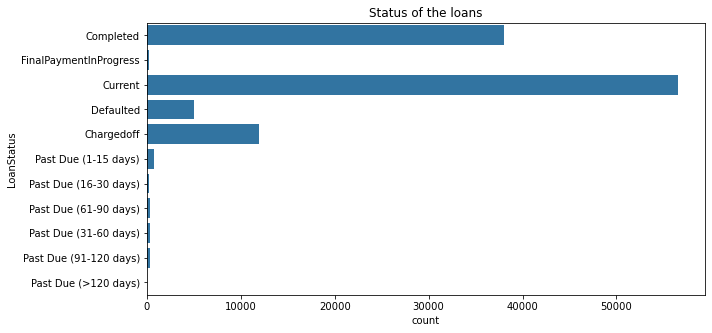

```python
# Explore the Loan Status Column. Since it is a categorical variable, I'll use the bar chart ensuring my variables are on the y axis.
plt.figure(figsize = (10, 5))
base_color = sb.color_palette()[0]
sb.countplot(data = n_loan, y = 'LoanStatus', color = base_color);
plt.title('Status of the loans');
```

There are more Loans that are current, i.e that have all the payments updated but not yet completed.

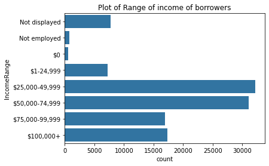

```python
# Lets plot income range
sb.countplot(data = n_loan, y = 'IncomeRange', color = base_color);
plt.title('Plot of Range of income of borrowers');
```

It is quite evident that the loans with income range of $25,000 - 49,999 are more rampant in the dataset. More investigation needs to be done to understand how income range of borrowers affects the Loan Status.

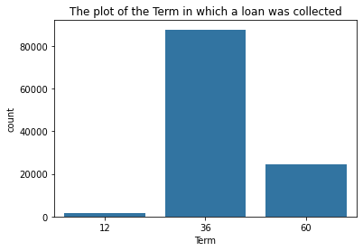

```python
# Plotting the Term column to visualize the values.
sb.countplot(data = n_loan, x = 'Term', color = base_color)
plt.title("The plot of the Term in which a loan was collected")
```

There are more Intermediate Term loan in the dataset. I'll move ahead to plotting BorrowerRate, to visualize the distribution.

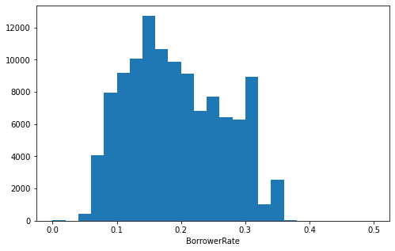

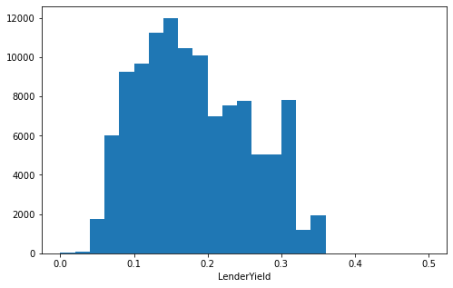

```python
# Plot the borrower rate, since it is a numeric value, I will plot with histogram
binsize = 0.02
bins = np.arange(0,n_loan['BorrowerRate'].max()+binsize, binsize)
plt.figure(figsize=[8, 5])
plt.hist(data = n_loan, x = 'BorrowerRate', bins = bins)
#plt.xlim([0,3.5])
plt.xlabel('BorrowerRate')

#Plotting the Lender Yield together
binsize = 0.02
bins = np.arange(0,n_loan['LenderYield'].max()+binsize, binsize)
plt.figure(figsize=[8, 5])
plt.hist(data = n_loan, x = 'LenderYield', bins = bins)
#plt.xlim([0,3.5])
plt.xlabel('LenderYield')
```

I plotted the borrower rate together with the Lender Yield, because I noticed that both almost have a similar implication. It is quite obvious that both Lender Yield and Borrower rate have almost a similar Trend. I will plot this using Scatter plot.

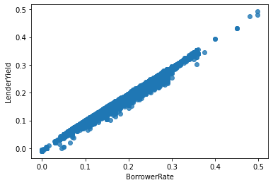

```python
# Plot Lender Yield and Borrower rate using scatter plot to compare variables.`
sb.regplot(data = n_loan, x = 'BorrowerRate', y = 'LenderYield', fit_reg = False);
```

Thus we settle for using the Borrower rate to determine the factors affecting Loan Status.

```
[ 0  2 16  1  7 13  6 15 20 19  3 18  8  4 11 14  5  9 17 10 12]
```

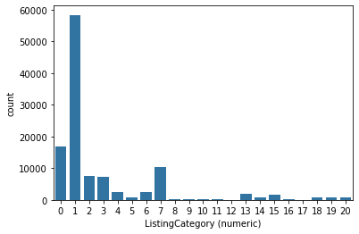

```python
# Plot listing category
print(n_loan['ListingCategory (numeric)'].unique())
def sbb(x):
    return sb.countplot(data = n_loan, x = x, color = base_color);
sbb('ListingCategory (numeric)');
```

```
2468
```

[figure not shown]

```python
print(n_loan['LoanOriginalAmount'].nunique())
# Plot loan Original Amount using hist
binsize = 1000
bins = np.arange(0,n_loan['LoanOriginalAmount'].max()+binsize, binsize)
plt.figure(figsize=[8, 5])
plt.hist(data = n_loan, x = 'LoanOriginalAmount', bins = bins)
#plt.xlim([0,3.5])
plt.xlabel('Loan Original Amount')
#sbb('IncomeRange');
```

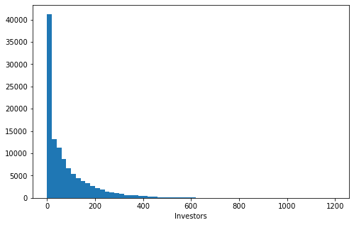

```python
# Plotting Investors column
binsize = 20
bins = np.arange(0,n_loan['Investors'].max()+binsize, binsize)
plt.figure(figsize=[8, 5])
plt.hist(data = n_loan, x = 'Investors', bins = bins)
#plt.xlim([0,3.5])
plt.xlabel('Investors')
#sbb('IncomeRange');
```

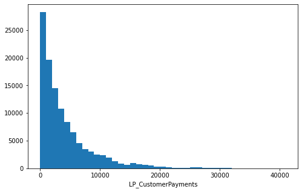

```python
# PLoting the prechargeoff payment column made by the borrower.`
binsize = 1000
bins = np.arange(0,n_loan['LP_CustomerPayments'].max()+binsize, binsize)
plt.figure(figsize=[8, 5])
plt.hist(data = n_loan, x = 'LP_CustomerPayments', bins = bins)
#plt.xlim([0,3.5])
plt.xlabel('LP_CustomerPayments')
#sbb('IncomeRange');
```

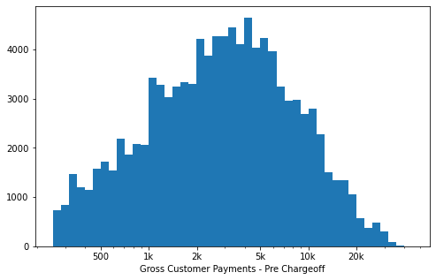

```python
# Due to the long tial, i will plot using a log scale
plt.figure(figsize=[8, 5])
log_binsize = 0.05
bins = 10 ** np.arange(2.4, np.log10(n_loan['LP_CustomerPayments'].max())+log_binsize, log_binsize)
plt.hist(data = n_loan, x = 'LP_CustomerPayments', bins = bins)
plt.xscale('log')
plt.xticks([ 500, 1e3, 2e3, 5e3, 1e4, 2e4], [500, '1k', '2k', '5k', '10k', '20k'])
plt.xlabel('Gross Customer Payments - Pre Chargeoff')
plt.show()
```

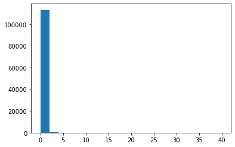

```python
# Plotting Recommendations columns
binsize = 2
bins = np.arange(0, n_loan.Recommendations.max()+ binsize, binsize)
plt.hist(data = n_loan, x = 'Recommendations', bins = bins)
```

I tried to plot the recommendation column, but the values are quite not interepretable, in the sense that there are more 0 recommendations, thus recommendations column won't affect the Loan Status.

```python
n_loan.columns
```

```
Index(['ListingKey', 'ListingNumber', 'ListingCreationDate', 'Term',
       'LoanStatus', 'BorrowerRate', 'LenderYield',
       'ListingCategory (numeric)', 'IsBorrowerHomeowner', 'IncomeRange',
       'StatedMonthlyIncome', 'LoanNumber', 'LoanOriginalAmount',
       'LoanOriginationDate', 'LoanOriginationQuarter', 'LP_CustomerPayments',
       'LP_CustomerPrincipalPayments', 'LP_InterestandFees', 'LP_ServiceFees',
       'LP_CollectionFees', 'LP_GrossPrincipalLoss', 'LP_NetPrincipalLoss',
       'LP_NonPrincipalRecoverypayments', 'Recommendations', 'Investors'],
      dtype='object')
```

### Discuss the distribution(s) of your variable(s) of interest. Were there any unusual points? Did you need to perform any transformations?

> Borrower Rate and LenderYield had almost a similar trend, so I visualized using a Scatter plot, i relaized they bhave almost the same trend, however , any effect that one has on the loan status, would surely affect the other. so i settled for one variable, Borrower Rate. I had to perform a transformation on the LP_CustomerPayments columns, after noticing a skew of the distribution.

## Bivariate Exploration

To start off with, I want to look at the pairwise correlations present between features in the data.

```python
numerical_variables = ['BorrowerRate', 'LP_CustomerPayments', 'Investors', 'LoanOriginalAmount']
categorical_variables = ['LoanStatus', 'IncomeRange', 'Term']
```

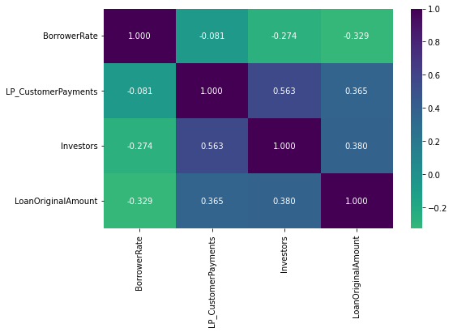

```python
# Correlation plot
plt.figure(figsize = [8, 5])
sb.heatmap(n_loan[numerical_variables].corr(), annot = True, fmt = '.3f',
           cmap = 'viridis_r', center = 0)
```

```
n_loan= (113937, 25)
n_loansamp.shape= (500, 25)
```

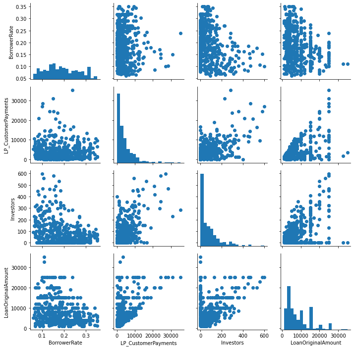

```python
# Plot pairwise correlation of the dataset using seaborns Pair Grid Function.
print("n_loan=",n_loan.shape)
# Selected 500 data from the  dataset, to reduce the noise
n_loansamp = n_loan.sample(n=500, replace = False)
print("n_loansamp.shape=",n_loansamp.shape)

g = sb.PairGrid(data = n_loansamp, vars = numerical_variables)
g = g.map_diag(plt.hist, bins = 20);
g.map_offdiag(plt.scatter)
```

Let's move on to looking at how LP_CustomersPayments and Investors correlate with the categorical variables.

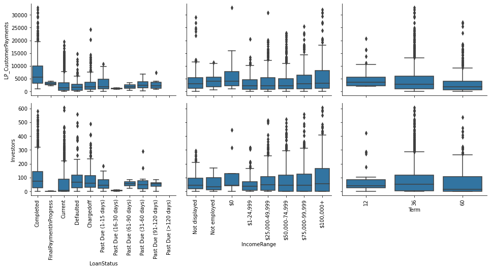

```python
# plot matrix of numeric features against caegorical features
n_loansamp = n_loan.sample(n=2000, replace = False)

# Creating box plots with seaborn's PairGrid.
def boxgrid(x, y, **kwargs):
    default_color = sb.color_palette()[0]
    sb.boxplot(x=x, y=y, color=default_color)
    plt.xticks(rotation = 90)
plt.figure(figsize = [10, 10])

g = sb.PairGrid(data = n_loansamp, y_vars = ['LP_CustomerPayments', 'Investors'], x_vars = categorical_variables,
                height = 3, aspect = 1.5);
g.map(boxgrid)
plt.show();
```

Finally, let's look at relationships between the three categorical features.

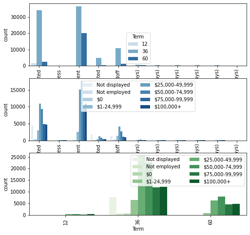

```python
# since there's only three subplots to create, using the full data should be fine.
plt.figure(figsize = [8, 8])

# subplot 1: LoanStatus vs Term
plt.subplot(3, 1, 1)
sb.countplot(data = n_loan, x = 'LoanStatus', hue = 'Term', palette = 'Blues')
plt.xticks(rotation = 90)

# subplot 2: LoanStatus vs IncomeRange
ax = plt.subplot(3, 1, 2)
sb.countplot(data = n_loan, x = 'LoanStatus', hue = 'IncomeRange', palette = 'Blues')
ax.legend(ncol = 2) # re-arrange legend to reduce overlapping
plt.xticks(rotation = 90)

# subplot 3: Term vs IncomeRange, use different color palette
ax = plt.subplot(3, 1, 3)
sb.countplot(data = n_loan, x = 'Term', hue = 'IncomeRange', palette = 'Greens')
ax.legend(loc = 1, ncol = 2) # re-arrange legend to remove overlapping
plt.xticks(rotation = 90)
plt.show()
```

However, on the Loan status/Income Range, Loans with Income Range around $50,000 - 74,999 have there payment to be up to date, while those with $25,000 - 49,999 have there loans completed.

I will move ahead to visualizing the numeric variables that have quite a good correlation.

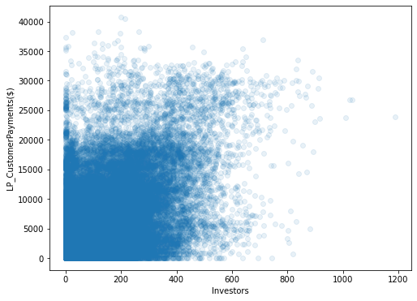

```python
# scatter plot of LP_CustomerPayments vs. Investors

plt.figure(figsize = [8, 6])
plt.scatter(data = n_loan, x = 'Investors', y = 'LP_CustomerPayments', alpha = 1/10)
plt.xlabel('Investors')
plt.ylabel('LP_CustomerPayments($)')
plt.show()
```

### Talk about some of the relationships you observed in this part of the investigation. How did the feature(s) of interest vary with other features in the dataset?

> From the plot of Term and Loan Status, completed intermediate term loans are much compared to other term loans. Thus we could partially deduce that Intermediate term loans are completed faster than any other loan Terms.

> However, on the Loan status/Income Range plot, Loans with Income Range around $50,000 - 74,999 have there payment to be up to date, while those with $25,000 - 49,999 have there loans completed.

### Did you observe any interesting relationships between the other features (not the main feature(s) of interest)?

> I noticed interesting relationships between the Lender Yield and Borrower Rate, i noticed how much they correlated, that any effect one of them have will be similar to other.

## Multivariate Exploration

```python
# creating heat maps with seaborn's PairGrid. """
def hist2dgrid(x, y, **kwargs):
    palette = kwargs.pop('color')
    plt.hist2d(x, y, cmap = palette, cmin = 0.5)
```

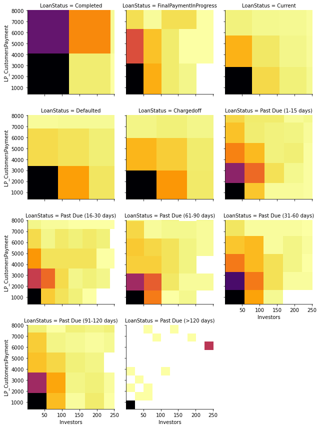

```python
# create faceted heat maps on levels of the Loan Variable
g = sb.FacetGrid(data = n_loan, col = 'LoanStatus', col_wrap = 3, height = 3)
g.map(hist2dgrid, 'Investors', 'LP_CustomerPayments', color = 'inferno_r')
g.set_xlabels('Investors')
g.set_ylabels('LP_CustomersPayment')

plt.show()
```

### Talk about some of the relationships you observed in this part of the investigation. Were there features that strengthened each other in terms of looking at your feature(s) of interest?

> In the overall distribution, there are less investors and LP_customerPayments, contributing to the visualizations. Thus, it is almost evident that less numeric variable doesnt have a thing to do with the loan status.

### Were there any interesting or surprising interactions between features?

> No, All the interactions have been discussed.

## Conclusions

> In this process of analysing the prosper dataset, I looked out to determining the factors that afffects the Loan status of the data, by first visualizing each single variable, including the variable of interest, and also performing a bivariate and multivariate visualization on the variables.

> I noticed that the nature of the terms of loans that are completed are Intermediate, i.e 36 months.

> In the process of exploration, i noticed that income range of people with 50,000 - 74,999, have there payment to be up to date, while those with income range around 25,000 - 49,999 are completed.

> Thus it is okay to deduce that the term of the loans and the Income Range of the borrowers affects the Loan Status.